# 🚀 Apache Kafka — Interview Preparation

> Comprehensive guide covering Kafka architecture, internals, and production patterns.

## 📑 Index

| # | Section |
| --- | --- |
| 1 | Batch vs Streaming |
| 2 | ZooKeeper vs KRaft |
| 3 | What is Apache Kafka? |
| 4 | Problems Kafka Solves — Tables |
| 5 | Use Cases & Non-Examples |
| 6 | What Kafka Is and Is NOT |
| 7 | Kafka vs Traditional Message Queues |
| 8 | Problems Kafka Solves (vs Queues) |
| 9 | Critical Clarification — Offset vs Ownership |
| 10 | Technology Positioning |
| 11 | Topics |
| 12 | Partitions |
| 13 | Offsets, Producers & Consumers (CLI) |
| 14 | Producers |
| 15 | Consumers |
| 16 | Consumer Groups |
| 17 | Kafka Internals — Brokers, Leaders, ISR |
| 18 | Message Keys & Serialization |
| 19 | Consumer Commits |
| 20 | Idempotent Producers |
| 21 | Delivery Semantics |
| 22 | Retention Policies |
| 23 | Log Compaction |

## 1. Batch vs Streaming

| Dimension | Batch Processing | Stream Processing |
| --- | --- | --- |
| **Trigger** | Scheduled (hourly, daily) | Continuous / event-driven |
| **Latency** | Minutes to hours | Milliseconds to seconds |
| **Use case** | Aggregations, reports, ETL | Real-time alerts, fraud, CDC |
| **Data window** | Fixed historical window | Sliding or tumbling window |
| **Examples** | Spark batch, Hive, dbt | Kafka Streams, Flink, Spark Streaming |

> **Key insight:** Streaming enables **immediate reaction**; batch enables **efficient aggregation**.  
> Kafka enables streaming — but batch systems remain essential and irreplaceable.

↑ Back to Index

## 2. ZooKeeper vs KRaft

| Dimension | ZooKeeper (Legacy) | KRaft (Modern) |
| --- | --- | --- |
| **Role** | External coordination service | Built-in Kafka metadata quorum |
| **Deployment** | Separate ZooKeeper cluster required | No external dependency |
| **Complexity** | High — two systems to operate | Low — single system |
| **Startup speed** | Slow metadata propagation | Fast — direct log replication |
| **Scale** | Limited partition count (~200k) | Millions of partitions |
| **Status** | Deprecated (Kafka 3.x) | Default from Kafka 3.3+ |

> **Key insight:** ZooKeeper is legacy baggage. KRaft represents Kafka maturing into a simpler, faster, fully self-managed system.  
> **Modern Kafka = KRaft. Anything else is transitional.**

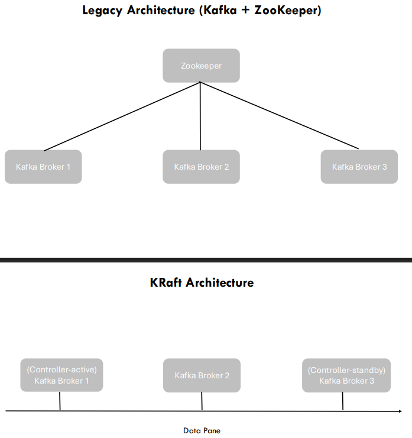

> ↑ Back to Index

## 3. What is Apache Kafka?

Apache Kafka is a **distributed, fault-tolerant event streaming platform** that:

- ✅ Accepts events from **producers**
- ✅ Persists events durably as an **ordered, append-only log**
- ✅ Allows **multiple consumers** to read the same events independently and at their own pace

> Kafka combines **messaging**, **durable storage**, and **streaming delivery** into a single system.  
> It is not just a message broker, and it is not just storage — it is **both, by design**.

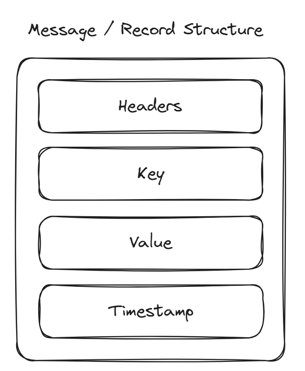

> ↑ Back to Index

## 4. Problems Kafka Solves

### Problem 1: Messaging Systems Without Persistence

| Dimension | Traditional Messaging | Kafka |
| --- | --- | --- |
| **Message lifecycle** | Deleted after consumption | Retained for configurable duration |
| **Replay capability** | None | Full replay at will |
| **Recovery guarantees** | Weak | Strong — log-based |
| **Data model** | Messages (ephemeral) | Events (stored) |

> **Consumption does not destroy data.**

### Problem 2: Storage Systems Without Real-Time Delivery

| Dimension | Databases / Data Lakes | Kafka |
| --- | --- | --- |
| **Write model** | Random writes | Append-only writes |
| **Read model** | Query-based (pull) | Sequential streaming (push-pull) |
| **Real-time delivery** | Not designed for it | Native — continuous reads |
| **Change propagation** | Polling or CDC bolt-on | First-class event stream |

> **Kafka bridges the gap between storage and real-time movement.**

### Problem 3: One Producer, Many Consumers

| Dimension | API / Point-to-Point | Kafka |
| --- | --- | --- |
| **Fan-out model** | Producer must explicitly duplicate | Write once, read by many |
| **Producer load** | Grows with each new consumer | Fixed regardless of consumer count |
| **Coupling** | Tight (producer knows consumers) | Decoupled |
| **Bottleneck risk** | Producer becomes bottleneck | None — log absorbs all reads |

> **Fan-out is a native property, not custom logic.**

↑ Back to Index

## 5. Use Cases & Non-Examples

### ✅ Use Kafka For

| Use Case | Why Kafka Fits |
| --- | --- |
| **Application logs** | High-throughput append, durable, replayable |
| **Metrics pipelines** | Fan-out to multiple monitoring systems |
| **CDC (Change Data Capture)** | Ordered, keyed events per entity |
| **Event-driven microservices** | Decoupled producers and consumers |
| **Audit trails** | Immutable, retained log |

### ❌ Do NOT Use Kafka For

| Non-Example | Why It Doesn't Fit |
| --- | --- |
| **CRUD APIs** | Kafka is not a request/response system |
| **Background job queues** | No task acknowledgement or visibility — use RabbitMQ / SQS |
| **Simple notification systems** | Overkill; push semantics are unnatural in Kafka |

↑ Back to Index

## 6. What Kafka Is and Is NOT

| Kafka IS | Kafka is NOT |
| --- | --- |
| A distributed event streaming platform | A request/response system |
| A durable, ordered log | A task queue |
| A fan-out backbone for systems | A relational or document database |
| A replay engine | A push notification service |
| A storage + delivery hybrid | A replacement for all messaging systems |

↑ Back to Index

## 7. Kafka vs Traditional Message Queues

| Dimension | Traditional Queue | Apache Kafka |
| --- | --- | --- |
| **Message lifecycle** | Deleted after consumption | Retained in durable log |
| **Replay** | Not possible | Full replay via offset reset |
| **Multiple consumers** | Requires message duplication | Native fan-out — all read the same log |
| **Data ownership** | Belongs to one consumer | Belongs to the log |
| **Ordering** | Per-queue FIFO | Per-partition ordered |
| **Consumer independence** | Coupled through deletion | Fully independent via offsets |

> The difference is not an implementation detail — it is about **data lifecycle and ownership**.

↑ Back to Index

## 8. Problems Kafka Solves (vs Queues)

### Problem 1: Fan-Out Without Duplication

| Model | Behavior |
| --- | --- |
| Traditional queue | One message → one consumer; fan-out = message copies |
| Kafka | One event → many consumers; fan-out is native |

### Problem 2: Replay and Recovery

| Model | On Crash / Replay Need |
| --- | --- |
| Traditional queue | Data gone — no recovery without external backup |
| Kafka | Seek to offset — full replay within retention window |

Kafka enables:

- 🔄 **Reprocessing** — re-run pipelines on historical data
- 📥 **Backfills** — hydrate new systems from existing events
- 🛠️ **Debugging** — inspect historical event sequences
- 🔁 **Consumer recovery** — restart from last committed offset

### Problem 3: Decoupled Consumption Speed

| Model | Slow Consumer Impact |
| --- | --- |
| Traditional queue | Blocks throughput; drains messages permanently |
| Kafka | Reads fast or slow; pause/resume; rewind — log is unaffected |

> **Separation of storage from consumption speed is impossible in delete-on-read systems.**

↑ Back to Index

## 9. Critical Clarification — Offset vs Ownership

| Concept | Queue Model | Kafka Model |
| --- | --- | --- |
| **What is tracked** | "Who consumed this message" | "Where is the consumer in the log" |
| **Data after read** | Gone — deleted | Still present in the log |
| **Multiple readers** | Requires duplication | Native — each reader has its own offset |
| **Recovery after crash** | Message lost or in DLQ | Seek back to last committed offset |

> **Kafka is position-based, not message-ownership-based.**  
> Queues cannot do this because the data no longer exists after consumption.

↑ Back to Index

## 10. Technology Positioning

| System | Category | Primary Use Case |
| --- | --- | --- |
| **RabbitMQ** | Task & message queue | Job queues, work distribution, RPC |
| **Amazon SQS** | Managed queue service | Decoupled microservice messaging |
| **Apache Kafka** | Distributed event log | Event streaming, CDC, fan-out, replay |

> **These systems solve different problems. None replace the others.**

### Decision Guide

| Scenario | Choose |
| --- | --- |
| Background jobs with acknowledgement | RabbitMQ / SQS |
| Fan-out to multiple systems | Kafka |
| Replay historical data | Kafka |
| Simple one-off task queue | SQS |
| Ordered, keyed event streams | Kafka |

↑ Back to Index

## 11. Topics

A **Topic** is a named, append-only stream of events in Kafka.

| Property | Detail |
| --- | --- |
| **Ordering** | Events written in order within a partition |
| **Deletion** | Events NOT deleted after being read |
| **Access** | Shared by multiple consumers simultaneously |
| **Purpose** | Data contract + unit of organization and governance |

### Why Topics Exist

| Reason | Explanation |
| --- | --- |
| **Data Separation** | Each logical stream is isolated |
| **Ownership & Governance** | Teams own topics like APIs |
| **Scaling & Lifecycle** | Retention, compaction, partitioning per topic |

### CLI — Create and List Topics

↑ Back to Index

```python
# Create a topic
# ./kafka-topics.sh \
#   --create \
#   --topic orders \
#   --partitions 3 \
#   --replication-factor 1 \
#   --bootstrap-server host.docker.internal:29092

# List all topics
# ./kafka-topics.sh \
#   --list \
#   --bootstrap-server host.docker.internal:29092

print("Topic CLI commands above — run in Kafka bin/ directory")
```

## 12. Partitions

A **partition** is a physically separate, ordered, append-only log inside a topic.  
All scalability and parallelism in Kafka exist only because of partitions.

| Property | Detail |
| --- | --- |
| **Structure** | Each topic divided into 1+ partitions |
| **Independence** | Written to and read from independently |
| **Ordering guarantee** | Within one partition only |
| **Global ordering** | ❌ Not guaranteed across partitions |

### Problems Partitions Solve

| Problem | Partition Solution |
| --- | --- |
| **Throughput limits** | Parallelise writes across multiple partitions |
| **Consumer scalability** | One consumer per partition; horizontal scaling via consumer groups |
| **Fault isolation** | Replicate per partition; failures isolated |

### CLI — Describe Topic

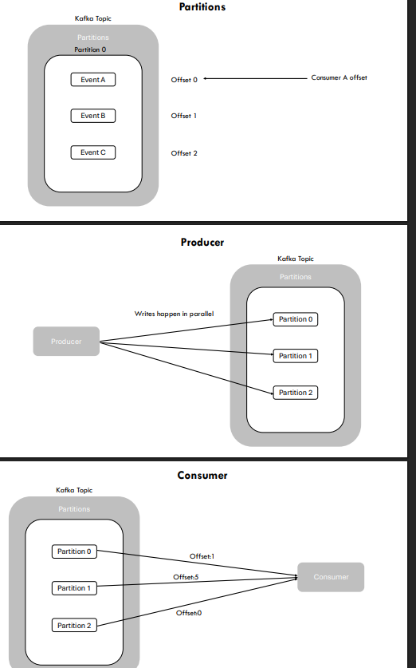

↑ Back to Index

```python
# Describe a topic — shows partitions, leaders, replicas, ISR
# ./kafka-topics.sh \
#   --describe \
#   --topic orders \
#   --bootstrap-server host.docker.internal:29092

# Output fields:
# Topic        → topic name
# Partition    → partition number
# Leader       → broker handling reads/writes
# Replicas     → all replica brokers
# ISR          → In-Sync Replicas (fully caught up)
# ELR          → Eligible Leader Replicas

print("Partition describe CLI — run in Kafka bin/ directory")
```

## 13. Offsets, Producers & Consumers (CLI)

An **offset** is a monotonically increasing position number representing where a consumer is within a partition.

| Concept | Detail |
| --- | --- |
| **Ownership** | Belongs to the consumer group, not the message |
| **Scope** | Tracked per partition |
| **Model** | Position-based (not message-ownership-based) |

### Consumer Lag Fields

| Field | Meaning |
| --- | --- |
| `CURRENT-OFFSET` | Where the consumer is now |
| `LOG-END-OFFSET` | Latest event in the partition |
| `LAG` | How far behind the consumer is |

### CLI Commands

↑ Back to Index

```python
# Start a console producer
# ./kafka-console-producer.sh \
#   --topic orders \
#   --bootstrap-server host.docker.internal:29092

# Start a console consumer (from beginning)
# ./kafka-console-consumer.sh \
#   --topic orders \
#   --group orders-consumer-group \
#   --from-beginning \
#   --bootstrap-server host.docker.internal:29092

# Inspect consumer group lag
# ./kafka-consumer-groups.sh \
#   --describe \
#   --group orders-consumer-group \
#   --bootstrap-server host.docker.internal:29092

print("Proves three critical facts:")
print("  1. Kafka tracks positions, not message deletion")
print("  2. Kafka knows exactly how far a consumer is behind")
print("  3. Messages still exist even after being consumed")
```

## 14. Producers

A **producer** is a client application that writes events into Kafka topics.

| Property | Detail |
| --- | --- |
| **Action** | Appends events to partitions inside topics |
| **Coupling** | Does not wait for consumers |
| **Reliability control** | Decided entirely by producer configuration |

> **Critical truth: Kafka itself does not decide reliability. Producers do.**

### Producer Configuration

| Config | Values | Effect |
| --- | --- | --- |
| `acks=0` | Fire-and-forget | Fastest, no durability guarantee |
| `acks=1` | Leader only | Leader confirms write |
| `acks=all` | Leader + all ISR | Highest durability |
| `retries` | Integer | Retry on transient failure |
| `enable_idempotence` | True/False | Prevent duplicate writes on retry |

> **Durability, duplication, and latency are producer-side decisions. Bad defaults create irreversible damage downstream.**

↑ Back to Index

```python
from kafka import KafkaProducer

producer = KafkaProducer(
    bootstrap_servers="host.docker.internal:29092",
    acks="all",              # durability — all ISR must confirm
    retries=5,               # resilience — retry on failure
    enable_idempotence=True  # no duplicates on retry
)

producer.send("orders", b"order_created")
producer.flush()
producer.close()

print("Producer configured with: acks=all | retries=5 | idempotence=True")
```

## 15. Consumers

A **consumer** is a client application that reads events from Kafka partitions by tracking offsets.

| Property | Detail |
| --- | --- |
| **Read model** | Sequential from partitions |
| **Position tracking** | Maintains own offset per partition |
| **Pull model** | Kafka never pushes — consumers pull |
| **Independence** | Each consumer decides when data is processed |

> **Kafka stores data. Consumers decide how and when to read it.**

### Consumer Configuration

| Config | Value | Meaning |
| --- | --- | --- |
| `auto_offset_reset` | `"earliest"` | Start from beginning if no offset exists |
| `auto_offset_reset` | `"latest"` | Only read new messages |
| `enable_auto_commit` | `True` | Kafka commits offsets automatically |
| `enable_auto_commit` | `False` | Manual commit control |
| `group_id` | string | Consumer group this consumer belongs to |

↑ Back to Index

```python
from kafka import KafkaConsumer

consumer = KafkaConsumer(
    "orders",
    bootstrap_servers="host.docker.internal:29092",
    group_id="consume_orders",
    auto_offset_reset="earliest",   # start from beginning if no offset
    enable_auto_commit=True         # auto-commit offsets
)

for msg in consumer:
    print(f"Received: {msg.value} | Partition: {msg.partition} | Offset: {msg.offset}")
```

## 16. Consumer Groups

A **consumer group** is a set of consumers that coordinate to read a topic together, where each partition is assigned to exactly one consumer within the group.

| Rule | Detail |
| --- | --- |
| **Partition assignment** | One consumer per partition per group |
| **Offset tracking** | Per consumer group |
| **Unit of parallelism** | Consumer group = one logical reader, many processes |

> Think of a consumer group as **one logical reader, implemented by many processes**.

### Problems Consumer Groups Solve

| Problem | Solution |
| --- | --- |
| **Throughput bottleneck** | Split partitions across consumers — horizontal scale |
| **Duplicate processing** | Each partition read by exactly one consumer in the group |
| **Fault tolerance** | Rebalance reassigns partitions when a consumer fails |

### Fan-Out vs Parallelism

| Goal | Pattern |
| --- | --- |
| **Scale processing** | More consumers in the same group |
| **Fan-out to multiple systems** | Multiple consumer groups (one per downstream system) |

> **Rule of thumb: Groups are for parallelism, not fan-out.**

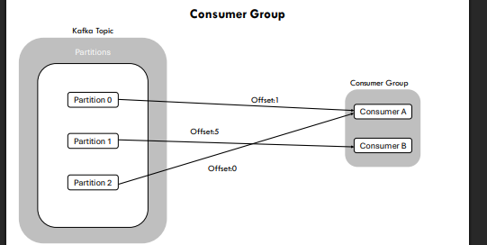

> ↑ Back to Index

## 17. Kafka Internals — Brokers, Leaders, Followers, ISR

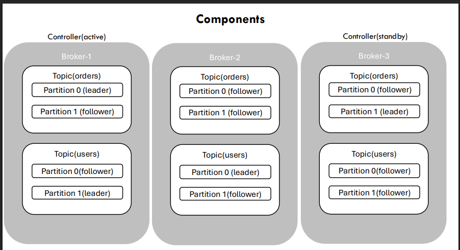

| Component | Role |
| --- | --- |
| **Broker** | Kafka server — stores and serves partition data |
| **Controller** | Special broker role managing cluster-wide coordination |
| **Partition** | Ordered log holding data for a topic |
| **Leader** | Authoritative replica for each partition — handles all reads/writes |
| **Follower** | Replicated copy — provides fault tolerance |
| **ISR** | In-Sync Replicas — alive and caught up, eligible for leader election |

### Broker Properties

| Property | Detail |
| --- | --- |
| **Stateful** | Each broker holds partition leaders and followers |
| **Symmetric** | Any broker can become controller or host leaders |
| **No master** | No designated master broker in traditional sense |

### Controller Facts

[output not shown]

### Write Flow (ISR)

```
Producer → Leader (writes to disk)
              ↓
         Followers replicate
              ↓
         ISR acknowledges
              ↓
         Write committed ✅
```

### Design Philosophy

> One leader per partition. Many followers for safety.  
> One controller for coordination. Many brokers for scale.  
> **No single point of failure.**

> ⚠️ Partitions are **never split across brokers** — a partition lives entirely on one broker (as leader) with replicas on others.

↑ Back to Index

## 18. Message Keys & Serialization

### Message Keys

A **message key** is an optional field Kafka uses to deterministically route a record to a partition.

| Fact | Detail |
| --- | --- |
| **Routing** | `hash(key) % partition_count` → same key always same partition |
| **Ordering** | All events for a key land in the same partition → ordered |
| **Stability** | Only valid while partition count is unchanged |

| Problem Solved | How Keys Help |
| --- | --- |
| **Ordering guarantees** | Events for same entity processed in order |
| **Consistent processing** | State machines per entity work correctly |
| **Predictable scaling** | Parallelism across entities, serial within entity |

### Common Key Choices

| Key | Use Case |
| --- | --- |
| `order_id` | All order events ordered per order |
| `user_id` | User activity stream |
| `account_id` | Financial event ordering |
| `device_id` | IoT telemetry per device |

### Serialization

| Fact | Detail |
| --- | --- |
| **Kafka stores** | Byte arrays only |
| **Producer does** | Serialize structured data → bytes |
| **Consumer does** | Deserialize bytes → structured data |
| **Kafka inspects** | Nothing — fully opaque |

| Format | Use Case |
| --- | --- |
| **JSON** | Simple, human-readable, schema-less |
| **Avro** | Schema registry, compact, schema evolution |
| **Protobuf** | High performance, typed, cross-language |
| **Bytes** | Raw / custom formats |

> **Serialization is not a formatting detail — it enables language-agnostic data exchange.**

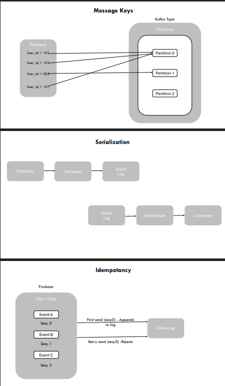

> ↑ Back to Index

## 19. Consumer Commits

A **consumer commit** records the offset position that a consumer group has successfully processed.

| Fact | Detail |
| --- | --- |
| **Storage** | Offsets stored by Kafka, not the consumer process |
| **Scope** | Per consumer group |
| **Resume point** | Committed offset determines where consumption resumes after restart |

### Commit Timing Risk

| Mistake | Consequence |
| --- | --- |
| Commit **too early** (before processing) | **Data loss** — failure skips unprocessed events |
| Commit **too late** (long after processing) | **Duplicate processing** on restart |

### Commit Strategies

| Strategy | Behaviour | Risk |
| --- | --- | --- |
| **Auto Commit** | Kafka commits on interval automatically | Commit may occur before processing completes → data loss |
| **Manual Commit** | Developer commits explicitly after success | Safe — commit happens only after successful processing |

> **Rule of thumb: If processing matters, auto-commit is unsafe. Manual commits win. Always.**

↑ Back to Index

```python
from kafka import KafkaConsumer

consumer = KafkaConsumer(
    "orders",
    bootstrap_servers="host.docker.internal:29092",
    group_id="orders_consume_manualoffset",
    enable_auto_commit=False,       # manual control
    auto_offset_reset="earliest"
)

for msg in consumer:
    print("Processing:", msg.value)
    # ... your business logic here ...
    consumer.commit()               # commit ONLY after successful processing
    print("Offset committed")
```

## 20. Idempotent Producers

An **idempotent producer** guarantees that even if a producer retries sending the same message, Kafka will write it **only once** to the log.

### How It Works

| Step | Detail |
| --- | --- |
| **Producer ID (PID)** | Assigned per producer session |
| **Sequence number** | Monotonically increasing, tagged on every message |
| **Broker tracking** | Tracks `(PID, sequence)` pairs per partition |
| **Duplicate detection** | Retry with same sequence number → broker rejects duplicate |

### Delivery Guarantee

| Guarantee | Provided By |
| --- | --- |
| At-least-once delivery | Default Kafka |
| No duplicate records at broker | `enable_idempotence=True` |

> ⚠️ **Important boundary:** Idempotence solves **producer → broker** duplication.  
> It does **not** solve consumer-side reprocessing.

> **Deduplication happens at the broker, not in your code.**

↑ Back to Index

```python
from kafka import KafkaProducer

producer = KafkaProducer(
    bootstrap_servers="host.docker.internal:29092",
    acks="all",
    retries=5,
    enable_idempotence=True   # broker deduplicates retries by (PID, sequence)
)

producer.send("orders", b"order-200")
producer.flush()
print("Message sent with idempotence enabled")
```

## 21. Delivery Semantics

**Delivery semantics** define how many times an event may be processed when failures occur.

| Semantic | Guarantee | Risk |
| --- | --- | --- |
| **At-most-once** | Processed 0 or 1 times | Data loss possible |
| **At-least-once** | Processed 1 or more times | Duplicates possible |
| **Exactly-once** | Processed exactly 1 time | Highest complexity |

> These are **not switches you flip** — they are emergent outcomes of:  
> **producer configuration + consumer commit strategy**

### Comparison Table

| Semantic | Producer Config | Consumer Config | Trade-Off |
| --- | --- | --- | --- |
| **At-most-once** | `acks=0`, no retries | Auto-commit before processing | Speed over correctness |
| **At-least-once** | `acks=all`, retries | Commit after processing | Simplicity with duplicates |
| **Exactly-once** | `enable_idempotence=True`, transactions | Manual commit in transaction | Precision with complexity |

> **At-least-once is the industry default.** Duplicates are normal — design for them.

### Exactly-Once Configuration

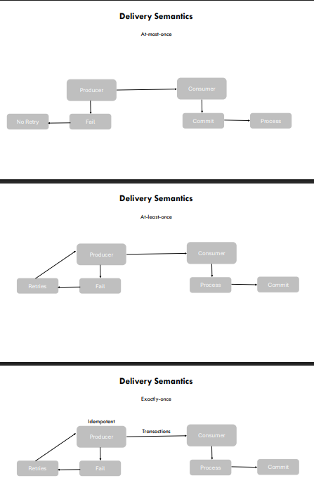

↑ Back to Index

```python
from kafka import KafkaProducer

# Exactly-once producer setup
producer = KafkaProducer(
    bootstrap_servers="host.docker.internal:29092",
    acks="all",
    retries=5,
    enable_idempotence=True,
    transactional_id="my-transactional-producer"
)

producer.init_transactions()
producer.begin_transaction()
producer.send("orders", b"order-300")
producer.commit_transaction()
print("Exactly-once transaction committed")
```

## 22. Retention Policies

**Retention policies** define how long data is stored in a topic and under what rules it is removed or compacted.

| Boundary | Detail |
| --- | --- |
| **Scope** | Per topic, not cluster-wide |
| **Randomness** | Kafka never deletes data randomly |
| **Control** | Only forgets data you explicitly tell it to forget |

### Retention Types

| Type | Config | Behaviour |
| --- | --- | --- |
| **Time-based** | `retention.ms` / `retention.hours` | Deletes data older than duration |
| **Size-based** | `retention.bytes` | Deletes oldest data when topic exceeds size |
| **Log compaction** | `cleanup.policy=compact` | Retains only latest value per key |

### CLI — Create Compacted Topic

↑ Back to Index

```python
# Create a log-compacted topic with time retention
# ./kafka-topics.sh \
#   --create \
#   --topic user-state \
#   --bootstrap-server host.docker.internal:29092 \
#   --partitions 1 \
#   --replication-factor 1 \
#   --config cleanup.policy=compact \
#   --config retention.ms=8640000

print("Retention policy examples:")
print("  retention.ms=86400000     → 1 day")
print("  retention.ms=604800000    → 7 days")
print("  retention.bytes=1073741824 → 1 GB cap")
print("  cleanup.policy=compact    → keep latest per key")
```

## 23. Log Compaction

**Log compaction** is a retention mechanism that ensures Kafka eventually keeps only the **latest record for each key** in a topic.

### How It Works

| Step | Detail |
| --- | --- |
| **Requirement** | Records must have keys |
| **Process** | Kafka periodically scans log segments in background |
| **Result** | For each key, older records discarded; latest value retained |
| **Model** | State convergence by key — not time-based deletion |

> Kafka is not deciding when data expires — it is deciding **which version of state is correct**.

### When to Use Log Compaction

| Use Case | Why It Fits |
| --- | --- |
| **User profiles** | Only current profile matters |
| **Feature flag topics** | Latest flag value per feature |
| **Configuration topics** | Current config per service |
| **CDC topics** | Latest row state per primary key |
| **Reference data** | Current master data per entity |

[figure not shown]

### Compaction vs Delete Comparison

| Dimension | Delete (Time/Size) | Compact |
| --- | --- | --- |
| **What's removed** | Old segments entirely | Old versions of duplicate keys |
| **What's kept** | Recent data within window | Latest value per key — forever |
| **Use case** | Event streams | State / entity topics |
| **Consumer expectation** | Time-bounded history | Complete current-state snapshot |

> **Log compaction turns a Kafka topic into a distributed, streaming key-value store.**

↑ Back to Index

| Topic | Key Points |
| --- | --- |
| **Message Size** | Keep messages **< 1 MB**. Do not store large files in Kafka; store files in S3 and send only metadata/pointers in Kafka. |
| **Single Broker Capacity** | Approximately **1 TB** storage and **1M messages/sec** (depends on hardware and message size). |
| **Horizontal Scaling** | Add more brokers to increase capacity and fault tolerance. Requires sufficient partitions to utilize new brokers. |
| **Partitioning Strategy** | `partition = hash(key) % num_partitions`. Choose keys that distribute traffic evenly and avoid hot partitions. |
| **Scale Topics** | Scale individual topics by increasing **partition count**, not the entire cluster. |
| **Hot Partition Solutions** | 1. No key (even distribution, no ordering) 2. Random salting 3. Compound key 4. Back pressure (slow producers). |
| **Replication** | Each partition has **1 leader + N followers**. Common replication factor = **3**. |
| **Durability** | Use `acks=all` to ensure all in-sync replicas (ISR) receive the message before acknowledgment. |
| **Offset Management** | Consumers commit offsets after processing and resume from the last committed offset after failure. |
| **Rebalancing** | If a consumer fails, Kafka redistributes partitions among remaining consumers automatically. |
| **Delivery Guarantee** | Default guarantee is **At-Least-Once Delivery**. |
| **Producer Retries** | Kafka supports automatic retries. Enable `idempotent=true` to avoid duplicates. |
| **Consumer Retries** | No built-in retries. Implement using **Retry Topics** and **Dead Letter Queues (DLQ)**. |
| **Batching** | Send multiple messages together to reduce network overhead and increase throughput. |
| **Compression** | Use **GZIP**, **Snappy**, or **LZ4** to reduce message size and improve throughput. |
| **Performance Optimization** | The most important optimization is choosing a good **partition key** for even distribution and maximum parallelism. |
| **Retention Policy** | Controlled by `retention.ms` and `retention.bytes`. Default retention is **7 days**. |
| **Interview Takeaway** | Kafka scales via **partitions**, achieves durability via **replication**, and reliability via **offsets, retries, and DLQs**. |